# Session 5: Intro to Visualization

Let me annotate the last plot:

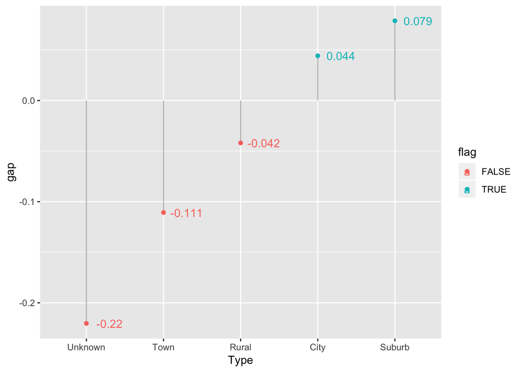

```r
lollipopGap4= lollipopGap3 +
              geom_text(aes(color=flag,label = round(gap,3)),
                        nudge_x=0.3) # push text to the right

lollipopGap4
```

The legend is plotting two symbols to represent the variables that give color to the text and the color of the dot, we can alter the previous code to avoid that:

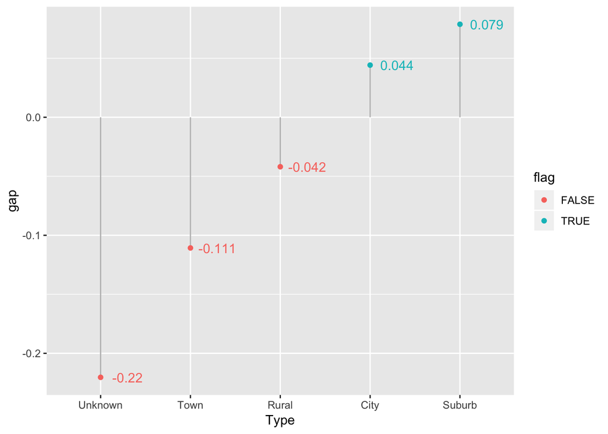

```r
lollipopGap4= lollipopGap3 +
              geom_text(aes(color=flag,label = round(gap,3)),
                        nudge_x=0.3,
                        show.legend = FALSE)

lollipopGap4
```

Another alternative to the histogram is the density plot. We had this:

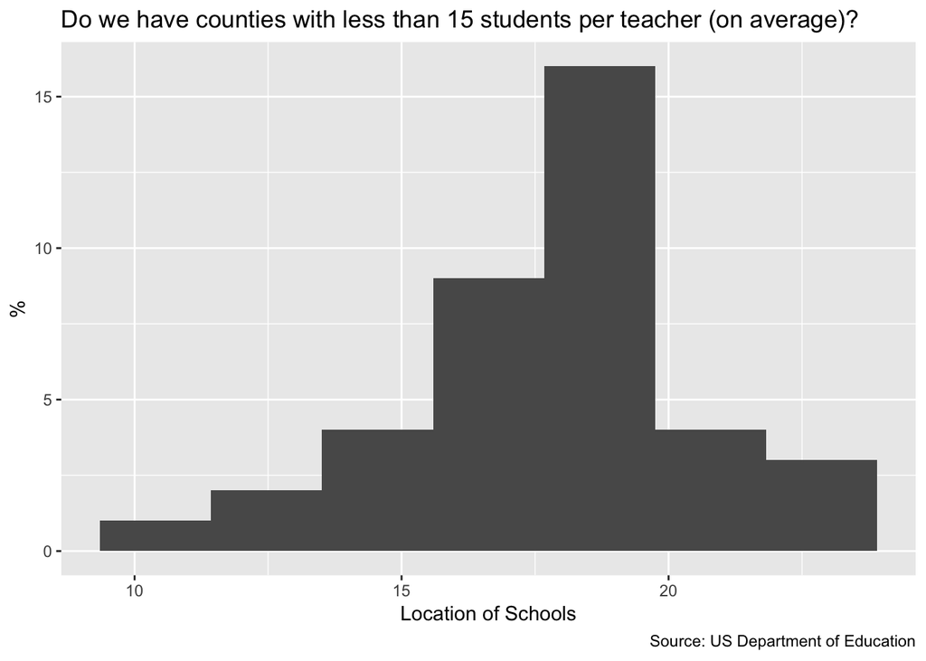

```r
#baseDec2= ggplot(meanValuesCounty,aes(x = means))
baseDecHist= baseDec2 + geom_histogram(bins=7)
baseDecHist2= baseDecHist + labs(title=titleText,
                               x = xaxisText,
                               y = yaxisText,
                               caption = sourceText)

baseDecHist2
```

Then, we need a couple of steps. First, represent the y values as density:

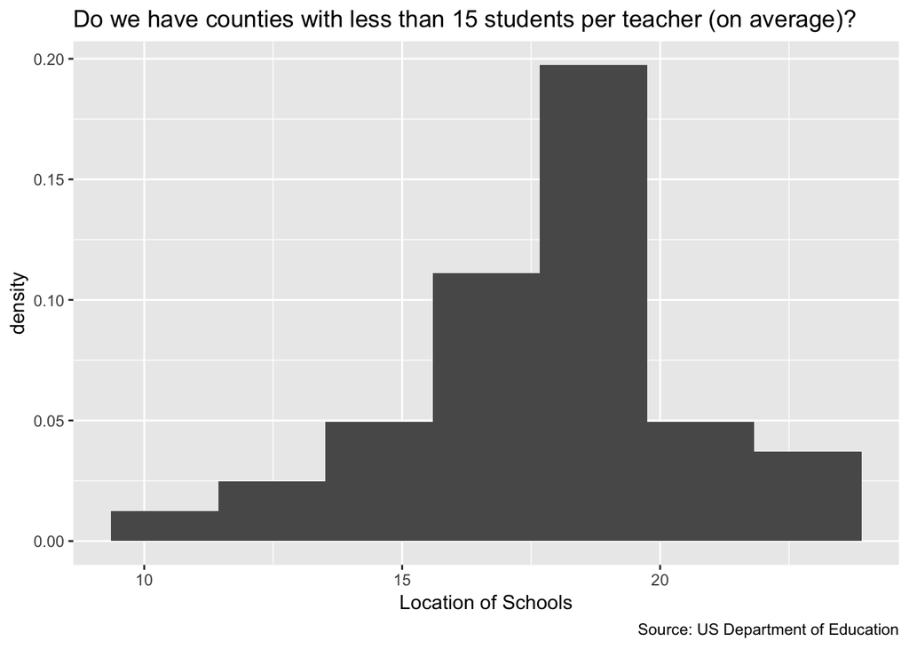

```r
baseDecHistDen= baseDec2 + geom_histogram(aes(y = ..density..),
                                       bins=7)

baseDecHistDen2= baseDecHistDen + labs(title=titleText,
                               x = xaxisText,
                               y = 'density',
                               caption = sourceText)

baseDecHistDen2
```

And now, plot the density:

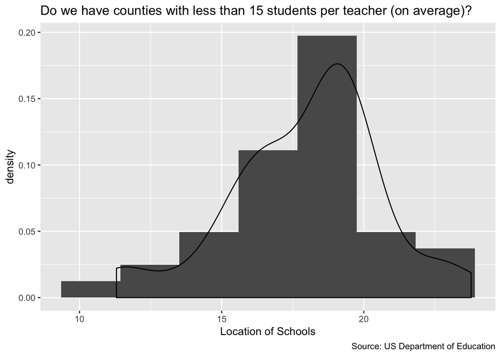

```r
baseDecHistDen3 = baseDecHistDen2 + geom_density()
baseDecHistDen3
```

We can improve:

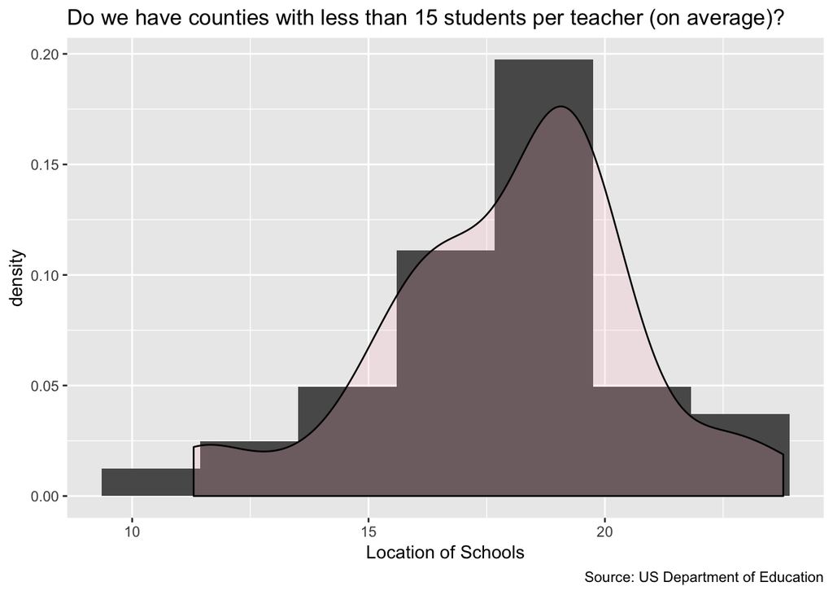

```r
baseDecHistDen3 = baseDecHistDen2 + geom_density(alpha = .2,
                                                 fill="pink")
baseDecHistDen3
```

- Go to page beginning
- [Go to Course schedule](https://ds4ps.org/ddmp-uw-class-spring-2019/schedule/)